# Validation

Erhebungsinstrument „Überzeugungen zum Verhältnis von Theorie und Praxis von Lehramtsstudierenden“

Jürgen Schneider

University of Tübingen

Ruben Kulcsar

University of Linz

// Further Cooperation

Thomas Fischer

University of Flensburg

Kathrin Rheinländer

University of Vechta

2024-04-19

[Link to OSF-Project](https://osf.io/jh6rx/)  
Questionnaire realized with [formr](https://formr.org/)  
see the questionnaire [here](https://showcase2.formr.org/)

# Preregistration

Available here: https://osf.io/2jw7m  
Preregistration dates after the data collection, last modification was - however - before data collection. I simply clicked on “save” and not on “register” at the time.

# Data import & cleaning

**Import**

```r
library(tidyverse)
library(psych)
library(rio)
library(lavaanPlot)
library(BayesFactor)
library(lavaan)
library(knitr)

valid <- rio::import("https://raw.githubusercontent.com/j-5chneider/uzvvtp-las/master/data/pilot2.csv")
```

**Delete empty rows/ rows of test run**

```r
valid <- valid %>%
  dplyr::filter(!is.na(lehramt))                 # only include students that completed the questionnaire
```

# Sample description

and editing/deleting unreasonable values (e.g. out of range data)

## Semester

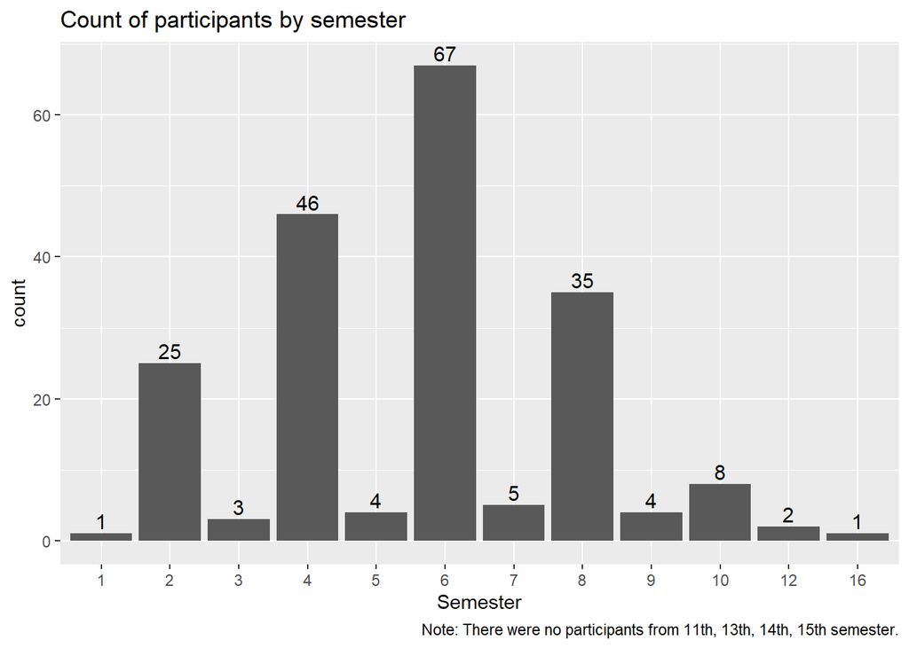

```r
# semester: no unreasonable values
ggplot(valid, aes(x = as.factor(semester))) +
  geom_bar() +
  labs(title = "Count of participants by semester",
       caption = "Note: There were no participants from 11th, 13th, 14th, 15th semester.") +
  xlab("Semester") +
  geom_text(aes(label = ..count..), stat = "count", vjust = -0.3, size = 4)
```

## Standort

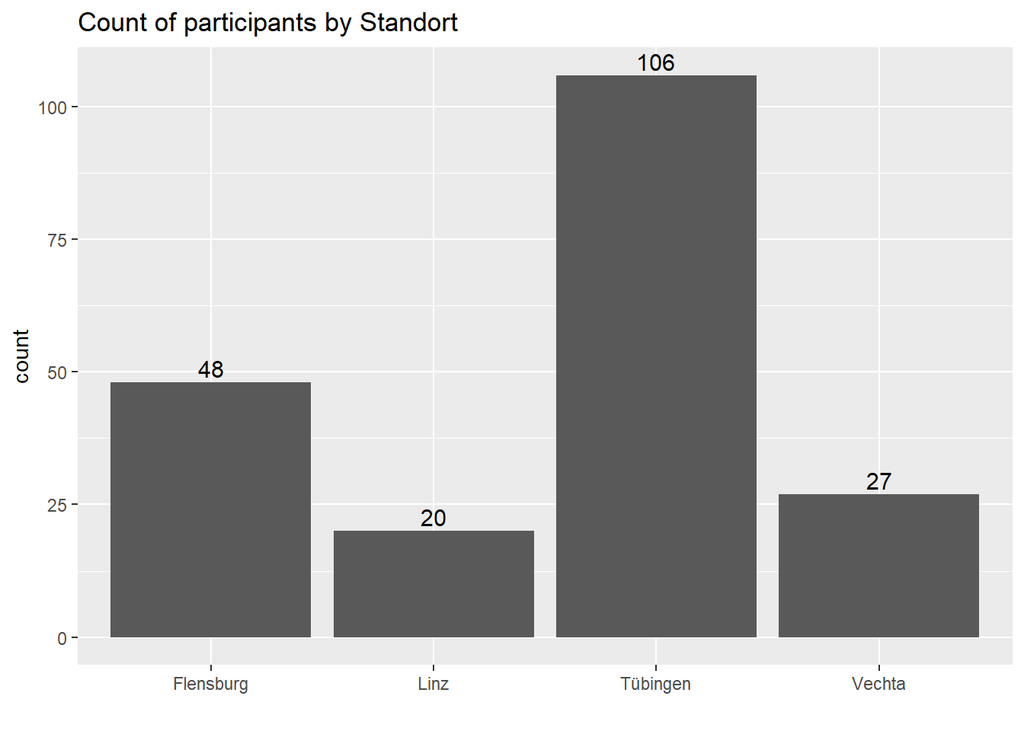

```r
ggplot(valid, aes(x = factor(standort, labels = c("Flensburg", "Linz", "Tübingen", "Vechta")))) +  # 1= Flensburg, 2= Linz, 3= München, 4= Stuttgart, 5= Tübingen, 6= Vechta, 7= andere
  geom_bar() +
  labs(title = "Count of participants by Standort") +
  xlab("") +
  geom_text(aes(label = ..count..), stat = "count", vjust = -0.3, size = 4)
```

## Subject

```r
fach_freq <- data.frame(table(valid$fach))
names(fach_freq) <- c("Combination of Subjects", "Frequency")
kable(fach_freq, format = "html")
```

| Combination of Subjects | Frequency |
| --- | --- |
| 11, 12, 15 | 1 |
| 12 | 4 |
| 12, 13 | 12 |
| 12, 13, 14 | 1 |
| 12, 13, 18 | 1 |
| 12, 14 | 1 |
| 12, 15 | 3 |
| 12, 17 | 1 |
| 12, 18 | 1 |
| 12, 18, 39 | 2 |
| 12, 29 | 1 |
| 12, 31 | 4 |
| 12, 35 | 1 |
| 12, 39 | 10 |
| 12, 40 | 2 |
| 12, 43 | 1 |
| 13 | 1 |
| 13, 14 | 1 |
| 13, 14, 23, 35 | 1 |
| 13, 17 | 1 |
| 13, 17, 34 | 1 |
| 13, 18 | 2 |
| 13, 18, 31 | 1 |
| 13, 23 | 1 |
| 13, 31 | 2 |
| 13, 37 | 4 |
| 13, 43 | 1 |
| 13, 44 | 2 |
| 13, 50 | 1 |
| 13, 52 | 1 |

[output cut: 85 more lines]

# Results FF2: CFA

## 4-factor-model (4-5 indicators)

Testing for factor structure and measurement invariance. We expect equal loading structure, but not equal intercept structure between treatment groups.

```r
## wrangle data ##
valid_l <- valid %>%
  mutate(id = 1:length(.$session),                                          # create ID
         tc = ifelse(tc_sr == 1 & tc_st == 2, 1,0)) %>%                     # create treatment check variable
  dplyr::select("flen_AN1":"rel_4_sr", "tc", "id", "semester", -"tc_sr", -"tc_st") %>%
  gather(key = "variable", value = "value", na.rm = T, 1:50) %>%                       # create long data set
  mutate(treat = case_when(                                                            # create treatment variable
                    str_sub(variable, -3, -1) ==  "_st" ~ "transfer",
                    str_sub(variable, -3, -1) ==  "_sr" ~ "relationierung",
                    TRUE ~ NA_character_
                    ),
         variable = case_when(                                                         # rename variable
                      str_sub(variable, -3, -1) ==  "_st" ~ str_sub(variable, 1, -4),
                      str_sub(variable, -3, -1) ==  "_sr" ~ str_sub(variable, 1, -4),
                      TRUE ~ variable
  )
  )

valid_cfa <- valid_l %>%
  dplyr::filter(!is.na(treat)) %>%
  spread(key = "variable", value = "value") %>%
  mutate(treat = case_when(
                    treat == "relationierung" ~ 1,
                    treat == "transfer"       ~ 0
  ))


# get treatment check variable and add to data set
addtc <- valid_l %>%
  dplyr::filter(variable == "tc") %>%
  mutate(tc = value) %>%
  dplyr::select(tc, id)

valid_cfa <- left_join(valid_cfa, addtc, by="id")


# the model
f4.model <- ' level: 1
                transfer_w   =~ t1*tfe_1 + t2*tfe_2 + t3*tfe_3 + t4*tfe_4 + t5*tfe_5
                selektion_w  =~ s1*sel_1 + s2*sel_2 + s3*sel_3 + s4*sel_4 + s5*sel_5
                enrichment_w =~ e1*enr_1 + e2*enr_2 + e3*enr_3 + e4*enr_4 + e5*enr_5
                relation_w   =~ r1*rel_1 + r2*rel_2 + r3*rel_3 + r4*rel_4

              level: 2
                transfer_b   =~ t1*tfe_1 + t2*tfe_2 + t3*tfe_3 + t4*tfe_4 + t5*tfe_5
                selektion_b  =~ s1*sel_1 + s2*sel_2 + s3*sel_3 + s4*sel_4 + s5*sel_5
                enrichment_b =~ e1*enr_1 + e2*enr_2 + e3*enr_3 + e4*enr_4 + e5*enr_5
                relation_b   =~ r1*rel_1 + r2*rel_2 + r3*rel_3 + r4*rel_4

                tfe_2 ~~ 0*tfe_2
                sel_5 ~~ sel_1
                enr_2 ~~ 0*enr_2
                rel_3 ~~ 0*rel_3
              '

fit_f4 <- sem(f4.model,
              data = valid_cfa,
              cluster = "id"
              )

lavaanPlot(model = fit_f4,
           node_options = list(shape = "box", fontname = "Helvetica"),
           edge_options = list(color = "grey"),
           coefs = TRUE)
```

[interactive chart not shown]

```r
summary(fit_f4, fit.measures = TRUE)
```

```
## lavaan 0.6.17 ended normally after 67 iterations
##
##   Estimator                                         ML
##   Optimization method                           NLMINB
##   Number of model parameters                       105
##   Number of equality constraints                    15
##
##                                                   Used       Total
##   Number of observations                           367         400
##   Number of clusters [id]                          197
##
## Model Test User Model:
##
##   Test statistic                               486.722
##   Degrees of freedom                               309
##   P-value (Chi-square)                           0.000
##
## Model Test Baseline Model:
##
##   Test statistic                              2185.145
##   Degrees of freedom                               342
##   P-value                                        0.000
##
## User Model versus Baseline Model:
##
##   Comparative Fit Index (CFI)                    0.904
##   Tucker-Lewis Index (TLI)                       0.893
##
## Loglikelihood and Information Criteria:
##
##   Loglikelihood user model (H0)             -10031.676
##   Loglikelihood unrestricted model (H1)      -9788.315
##
##   Akaike (AIC)                               20243.352
##   Bayesian (BIC)                             20594.835
##   Sample-size adjusted Bayesian (SABIC)      20309.299
##
## Root Mean Square Error of Approximation:
##
##   RMSEA                                          0.040
```

[output cut: 158 more lines]

```
##    .sel_2             0.255    0.079    3.215    0.001
##    .sel_3             0.043    0.066    0.662    0.508
##    .sel_4             0.025    0.067    0.376    0.707
##    .sel_5             0.201    0.088    2.285    0.022
##    .enr_1             0.064    0.081    0.794    0.427
##    .enr_3             0.079    0.081    0.970    0.332
##    .enr_4             0.140    0.081    1.724    0.085
##    .enr_5             0.138    0.103    1.336    0.182
##    .rel_1             0.175    0.070    2.497    0.013
##    .rel_2             0.092    0.064    1.444    0.149
##    .rel_4             0.036    0.058    0.628    0.530
##     transfer_b        0.281    0.073    3.867    0.000
##     selektion_b       0.504    0.096    5.275    0.000
##     enrichment_b      0.610    0.109    5.621    0.000
##     relation_b        0.297    0.071    4.211    0.000
```

## 4-factor-model (4 indicators)

Ausschluss von enr_5, tfe_4, sel_2 aufgrund geringer Ladung und inhaltlich geringer Passung

- tfe_4: Voraussetzung stark betont
- enr_5: bei anderen: Differenz betont
- sel_2: aktive Lehrerrolle

```r
# Ausschluss von enr_5, tfe_4, sel_2 aufgrund geringer Ladung und inhaltlich geringer Passung
# tfe_4: Voraussetzung stark betont
# enr_5: bei anderen: Differenz betont
# sel_2: aktive Lehrerrolle
f4.model2 <- 'level: 1
                transfer_w   =~ t1*tfe_1 + t2*tfe_2 + t3*tfe_3 + t5*tfe_5
                selektion_w  =~ s1*sel_1 + s3*sel_3 + s4*sel_4 + s5*sel_5
                enrichment_w =~ e1*enr_1 + e2*enr_2 + e3*enr_3 + e4*enr_4
                relation_w   =~ r1*rel_1 + r2*rel_2 + r3*rel_3 + r4*rel_4

              level: 2
                transfer_b   =~ t1*tfe_1 + t2*tfe_2 + t3*tfe_3 + t5*tfe_5
                selektion_b  =~ s1*sel_1 + s3*sel_3 + s4*sel_4 + s5*sel_5
                enrichment_b =~ e1*enr_1 + e2*enr_2 + e3*enr_3 + e4*enr_4
                relation_b   =~ r1*rel_1 + r2*rel_2 + r3*rel_3 + r4*rel_4

                tfe_2 ~~ 0*tfe_2
                sel_5 ~~ sel_1
                enr_2 ~~ 0*enr_2
                rel_3 ~~ 0*rel_3
             '



fit_f4.2 <- sem(f4.model2,
              data = valid_cfa,
              cluster = "id",
              std.lv=TRUE
              )

lavaanPlot(model = fit_f4.2,
           node_options = list(shape = "box", fontname = "Helvetica"),
           edge_options = list(color = "grey"),
           coefs = TRUE)
```

[interactive chart not shown]

```r
summary(fit_f4.2, fit.measures = TRUE)
```

```
## lavaan 0.6.17 ended normally after 58 iterations
##
##   Estimator                                         ML
##   Optimization method                           NLMINB
##   Number of model parameters                        90
##   Number of equality constraints                    16
##
##                                                   Used       Total
##   Number of observations                           373         400
##   Number of clusters [id]                          197
##
## Model Test User Model:
##
##   Test statistic                               298.755
##   Degrees of freedom                               214
##   P-value (Chi-square)                           0.000
##
## Model Test Baseline Model:
##
##   Test statistic                              1708.532
##   Degrees of freedom                               240
##   P-value                                        0.000
##
## User Model versus Baseline Model:
##
##   Comparative Fit Index (CFI)                    0.942
##   Tucker-Lewis Index (TLI)                       0.935
##
## Loglikelihood and Information Criteria:
##
##   Loglikelihood user model (H0)              -8565.580
##   Loglikelihood unrestricted model (H1)      -8416.203
##
##   Akaike (AIC)                               17279.160
##   Bayesian (BIC)                             17569.357
##   Sample-size adjusted Bayesian (SABIC)      17334.577
##
## Root Mean Square Error of Approximation:
##
##   RMSEA                                          0.033
```

[output cut: 143 more lines]

```
##    .tfe_5             0.352    0.070    5.034    0.000
##    .sel_1             0.122    0.073    1.670    0.095
##    .sel_3             0.068    0.069    0.987    0.324
##    .sel_4             0.017    0.071    0.244    0.807
##    .sel_5             0.200    0.090    2.231    0.026
##    .enr_1             0.079    0.085    0.924    0.355
##    .enr_3             0.164    0.087    1.881    0.060
##    .enr_4             0.119    0.077    1.545    0.122
##    .rel_1             0.164    0.070    2.347    0.019
##    .rel_2             0.116    0.064    1.817    0.069
##    .rel_4             0.039    0.058    0.671    0.502
##     transfer_b        1.000
##     selektion_b       1.000
##     enrichment_b      1.000
##     relation_b        1.000
```

### Standardized Solution

```r
standardizedSolution(fit_f4.2)
```

```
##              lhs op          rhs label est.std    se      z pvalue ci.lower
## 1     transfer_w =~        tfe_1    t1   0.517 0.048 10.779  0.000    0.423
## 2     transfer_w =~        tfe_2    t2   0.605 0.045 13.499  0.000    0.518
## 3     transfer_w =~        tfe_3    t3   0.554 0.048 11.449  0.000    0.459
## 4     transfer_w =~        tfe_5    t5   0.629 0.052 12.037  0.000    0.527
## 5    selektion_w =~        sel_1    s1   0.572 0.042 13.697  0.000    0.490
## 6    selektion_w =~        sel_3    s3   0.577 0.042 13.814  0.000    0.495
## 7    selektion_w =~        sel_4    s4   0.660 0.041 15.915  0.000    0.579
## 8    selektion_w =~        sel_5    s5   0.569 0.042 13.402  0.000    0.486
## 9   enrichment_w =~        enr_1    e1   0.531 0.042 12.782  0.000    0.450
## 10  enrichment_w =~        enr_2    e2   0.549 0.038 14.263  0.000    0.474
## 11  enrichment_w =~        enr_3    e3   0.549 0.042 13.033  0.000    0.467
## 12  enrichment_w =~        enr_4    e4   0.575 0.043 13.495  0.000    0.492
## 13    relation_w =~        rel_1    r1   0.469 0.043 10.848  0.000    0.385
## 14    relation_w =~        rel_2    r2   0.548 0.043 12.619  0.000    0.463
```

[output cut: 237 more lines]

## Reliability

```r
## McDonalds Omega for these factors ##

# Transfer
rel_data4.1.0 <- valid_cfa %>%
  dplyr::filter(treat == 0) %>%
  dplyr::select("tfe_1" , "tfe_2" , "tfe_3" , "tfe_5")

rel_tr_ctml <- MBESS::ci.reliability(rel_data4.1.0)$est
rel_tr_ctml_l <- MBESS::ci.reliability(rel_data4.1.0)$ci.lower
rel_tr_ctml_u <- MBESS::ci.reliability(rel_data4.1.0)$ci.upper

rel_data4.1.1 <- valid_cfa %>%
  dplyr::filter(treat == 1) %>%
  dplyr::select("tfe_1" , "tfe_2" , "tfe_3" , "tfe_5")

rel_tr_stp <- MBESS::ci.reliability(rel_data4.1.1)$est
rel_tr_stp_l <- MBESS::ci.reliability(rel_data4.1.1)$ci.lower
rel_tr_stp_u <- MBESS::ci.reliability(rel_data4.1.1)$ci.upper

# Selektion
rel_data4.2.0 <- valid_cfa %>%
  dplyr::filter(treat == 0) %>%
  dplyr::select("sel_1" , "sel_3" , "sel_4" , "sel_5")

rel_se_ctml <- MBESS::ci.reliability(rel_data4.2.0)$est
rel_se_ctml_l <- MBESS::ci.reliability(rel_data4.2.0)$ci.lower
rel_se_ctml_u <- MBESS::ci.reliability(rel_data4.2.0)$ci.upper

rel_data4.2.1 <- valid_cfa %>%
  dplyr::filter(treat == 1) %>%
  dplyr::select("sel_1" , "sel_3" , "sel_4" , "sel_5")

rel_se_stp <- MBESS::ci.reliability(rel_data4.2.1)$est
rel_se_stp_l <- MBESS::ci.reliability(rel_data4.2.1)$ci.lower
rel_se_stp_u <- MBESS::ci.reliability(rel_data4.2.1)$ci.upper


# Enrichment
rel_data4.3.0 <- valid_cfa %>%
  dplyr::filter(treat == 0) %>%
  dplyr::select("enr_1" , "enr_2" , "enr_3" , "enr_4")

rel_en_ctml <- MBESS::ci.reliability(rel_data4.3.0)$est
rel_en_ctml_l <- MBESS::ci.reliability(rel_data4.3.0)$ci.lower
rel_en_ctml_u <- MBESS::ci.reliability(rel_data4.3.0)$ci.upper

rel_data4.3.1 <- valid_cfa %>%
  dplyr::filter(treat == 1) %>%
  dplyr::select("enr_1" , "enr_2" , "enr_3" , "enr_4")

rel_en_stp <- MBESS::ci.reliability(rel_data4.3.1)$est
rel_en_stp_l <- MBESS::ci.reliability(rel_data4.3.1)$ci.lower
rel_en_stp_u <- MBESS::ci.reliability(rel_data4.3.1)$ci.upper

# Relationierung
rel_data4.4.0 <- valid_cfa %>%
  dplyr::filter(treat == 0) %>%
  dplyr::select("rel_1" , "rel_2" , "rel_3" , "rel_4")

rel_re_ctml <- MBESS::ci.reliability(rel_data4.4.0)$est
rel_re_ctml_l <- MBESS::ci.reliability(rel_data4.4.0)$ci.lower
rel_re_ctml_u <- MBESS::ci.reliability(rel_data4.4.0)$ci.upper

rel_data4.4.1 <- valid_cfa %>%
  dplyr::filter(treat == 1) %>%
  dplyr::select("rel_1" , "rel_2" , "rel_3" , "rel_4")

rel_re_stp <- MBESS::ci.reliability(rel_data4.4.1)$est
rel_re_stp_l <- MBESS::ci.reliability(rel_data4.4.1)$ci.lower
rel_re_stp_u <- MBESS::ci.reliability(rel_data4.4.1)$ci.upper
```

- **Transfer**
  - **McDonalds** $\sf{\omega_{CTML}}$= 0.621, **95%CI**[NA, NA]
  - **McDonalds** $\sf{\omega_{STP}}$= 0.818, **95%CI**[NA, NA]
- **Selektion**
  - **McDonalds** $\sf{\omega_{CTML}}$= 0.797, **95%CI**[NA, NA]
  - **McDonalds** $\sf{\omega_{STP}}$= 0.834, **95%CI**[NA, NA]
- **Enrichment**
  - **McDonalds** $\sf{\omega_{CTML}}$= 0.756, **95%CI**[NA, NA]
  - **McDonalds** $\sf{\omega_{STP}}$= 0.783, **95%CI**[NA, NA]
- **Relationierung**
  - **McDonalds** $\sf{\omega_{CTML}}$= 0.784, **95%CI**[NA, NA]
  - **McDonalds** $\sf{\omega_{STP}}$= 0.731, **95%CI**[NA, NA]

## Check 4 indicators with Study 1 data

Let’s see, if the data from item selection wave (exploratory, first data collection wave) fits the model with 4 indicators each factor.

```r
# unfortunately I cannot share the data via this file
# however you can access the data on [link pending]
itemsel <- read_csv2(file = "https://raw.githubusercontent.com/j-5chneider/uzvvtp-las/master/data/pilot1.csv")

# rename variables to fit latest labels
itemsel <- itemsel %>%
  mutate(tfe_1 = tfe_tfe_02,
         tfe_2 = tfe_tfe_03,
         tfe_3 = tfe_tfe_08,
         tfe_4 = tfe_did_01,
         tfe_5 = tfe_did_05,
         sel_1 = tfo_sel_01,
         sel_2 = tfo_sel_02,
         sel_3 = tfo_sel_04,
         sel_4 = tfo_sel_08,
         sel_5 = tfo_sel_09,
         enr_1 = tfo_enr_01,
         enr_2 = tfo_enr_02,
         enr_3 = tfo_enr_03,
         enr_4 = tfo_enr_04,
         enr_5 = tfo_enr_05,
         rel_1 = rel_rel_02,
         rel_2 = rel_rel_03,
         rel_3 = rel_rel_08,
         rel_4 = rel_rel_09)


f4.itemsel <- ' transfer   =~ tfe_1 + tfe_2 + tfe_3 + tfe_5
                selektion  =~ sel_1 + sel_3 + sel_4 + sel_5
                enrichment =~ enr_1 + enr_2 + enr_3 + enr_4
                relation   =~ rel_1 + rel_2 + rel_3 + rel_4

                # tfe_2 ~~ 0*tfe_2  # Heywood Cases
                # sel_5 ~~ sel_1
                # enr_2 ~~ 0*enr_2
                # rel_3 ~~ 0*rel_3
             '


# without restrictions
fit_itemsel <- sem(f4.itemsel,
                   data = itemsel,
                   # cluster = "id",      # there is no multilevel structure in wave 1
                   std.lv=TRUE
                   )

lavaanPlot(model = fit_itemsel,
          node_options = list(shape = "box", fontname = "Helvetica"),
          edge_options = list(color = "grey"),
          coefs = TRUE)
```

[interactive chart not shown]

```r
summary(fit_itemsel, fit.measures = TRUE)
```

```
## lavaan 0.6.17 ended normally after 18 iterations
##
##   Estimator                                         ML
##   Optimization method                           NLMINB
##   Number of model parameters                        38
##
##                                                   Used       Total
##   Number of observations                           203         399
##
## Model Test User Model:
##
##   Test statistic                               162.236
##   Degrees of freedom                                98
##   P-value (Chi-square)                           0.000
##
## Model Test Baseline Model:
##
##   Test statistic                              1263.053
##   Degrees of freedom                               120
##   P-value                                        0.000
##
## User Model versus Baseline Model:
##
##   Comparative Fit Index (CFI)                    0.944
##   Tucker-Lewis Index (TLI)                       0.931
##
## Loglikelihood and Information Criteria:
##
##   Loglikelihood user model (H0)              -4818.189
##   Loglikelihood unrestricted model (H1)      -4737.072
##
##   Akaike (AIC)                                9712.379
##   Bayesian (BIC)                              9838.280
##   Sample-size adjusted Bayesian (SABIC)       9717.887
##
## Root Mean Square Error of Approximation:
##
##   RMSEA                                          0.057
##   90 Percent confidence interval - lower         0.041
##   90 Percent confidence interval - upper         0.072
```

[output cut: 55 more lines]

```
##    .sel_3             0.641    0.101    6.354    0.000
##    .sel_4             0.843    0.117    7.226    0.000
##    .sel_5             1.279    0.149    8.565    0.000
##    .enr_1             0.987    0.129    7.660    0.000
##    .enr_2             0.911    0.111    8.185    0.000
##    .enr_3             0.815    0.117    6.969    0.000
##    .enr_4             1.455    0.159    9.129    0.000
##    .rel_1             0.778    0.088    8.857    0.000
##    .rel_2             0.558    0.079    7.066    0.000
##    .rel_3             0.692    0.089    7.781    0.000
##    .rel_4             0.581    0.079    7.319    0.000
##     transfer          1.000
##     selektion         1.000
##     enrichment        1.000
##     relation          1.000
```

# Results FF3: Experimental Study

We realized two different stimuli preceding a run through the instrument each. The stimuli are descriptions of two theories from education relevant to classroom practice: Cognitive Theory of Multimedia Learning (CTML) vs. Strukturtheoretische Professionstheorie (SPT). The conditions are varied within person and randomized in their order between person. The conditions were designed to have an effect on the subscale “Transfer”: The short description in the CTML-condition was written to be especially suitable to beliefs of “Transfer”. In this subscale we thus expect ratings to be higher in the CTML-condition (vs. SPT-condition).

For the other subscales results will be computed exploratory.

## The stimuli (German)

- **CTML group**: “Der „Spatial Contiguity Effect“ aus der Theorie des multimedialen Lernens, trifft Aussagen über die Kombination von Text und Bild in Lernmaterialien, beispielsweise bei der Gestaltung von Arbeitsblättern. Hierfür tragen Schroeder & Cenkci (2018) Befunde zusammen, ob Bilder und erklärender Text separat (getrennt nebeneinander) oder integriert (einzelne Textstücke direkt an relevanter Stelle im Bild) den Lernerfolg besser fördern. Das Ergebnis zeigt, dass integrierte Darstellungen einen positiven Effekt auf die Lernleistung besitzen. Dies gilt für computerbasierte Darstellungen, aber besonders für Darstellungen auf Arbeitsblättern. Wurden mobile Endgeräte verwendet, so konnte kein Unterschied in der Lernleistung zwischen den beiden Darstellungsformen festgestellt werden.”
- **SPT group**: “Im strukturtheoretischen Ansatz zur Professionalität im Lehrberuf adressiert Helsper (2004) das „Arbeitsbündnis zwischen Lehrperson und Schüler/-in“. Der Lehrerberuf ist aus dieser Perspektive durch Aufgaben und Anforderungen geprägt, die in sich widersprüchlich sind, also per se nicht aufgelöst werden können. So wird an Lehrpersonen beispielsweise die Anforderung gerichtet, sich als Person auf Lernende einzulassen und Nähe aufzubauen, andererseits müssen sie jedoch ihrer Rolle als Lehrperson gerecht werden, die z.B. bei der Notengebung eine gewisse Distanz gebietet (Nähe-Distanz-Antinomie). Beide Anforderungen vollauf zu realisieren ist nicht möglich und so scheint es für Lehrpersonen unmöglich „richtig“ zu handeln. Professionelles Handeln von Lehrpersonen äußert sich folglich darin, diese Widersprüche auszuhalten und sie sachgerecht zu bewältigen.”

## Frequentist Data analysis

```r
valid_exp <- valid_cfa %>%
  dplyr::filter(tc == 1)    # only include participants who
                            # answered the treatment check correctly

# Ausschluss von enr_5, tfe_4, sel_2 aufgrund geringer Ladung
exp.model <- 'level: 1
                transfer_w   =~ tfe_1 + tfe_2 + tfe_3 + tfe_5
                selektion_w  =~ sel_1 + sel_3 + sel_4 + sel_5
                enrichment_w =~ enr_1 + enr_2 + enr_3 + enr_4
                relation_w   =~ rel_1 + rel_2 + rel_3 + rel_4

                transfer_w ~ treat
                selektion_w ~ treat
                enrichment_w ~ treat
                relation_w ~ treat

              level: 2
                transfer_b   =~ tfe_1 + tfe_2 + tfe_3 + tfe_5
                selektion_b  =~ sel_1 + sel_3 + sel_4 + sel_5
                enrichment_b =~ enr_1 + enr_2 + enr_3 + enr_4
                relation_b   =~ rel_1 + rel_2 + rel_3 + rel_4

                tfe_2 ~~ 0*tfe_2
                sel_5 ~~ sel_1
                sel_5 ~~ 0*sel_5       # new in this model: Haywood Case
                enr_2 ~~ 0*enr_2
                rel_3 ~~ 0*rel_3
            '

fit_exp <- sem(exp.model,
               data = valid_exp,
               cluster = "id"
               )

lavaanPlot(model = fit_exp,
          node_options = list(shape = "box", fontname = "Helvetica"),
          edge_options = list(color = "grey"),
          coefs = TRUE)
```

[interactive chart not shown]

```r
# options(max.print=2000)
standardizedSolution(fit_exp)
```

```
##              lhs op          rhs est.std    se       z pvalue ci.lower ci.upper
## 1     transfer_w =~        tfe_1   0.611 0.063   9.656  0.000    0.487    0.735
## 2     transfer_w =~        tfe_2   0.829 0.068  12.107  0.000    0.695    0.964
## 3     transfer_w =~        tfe_3   0.405 0.083   4.865  0.000    0.242    0.568
## 4     transfer_w =~        tfe_5   0.529 0.073   7.205  0.000    0.385    0.672
## 5    selektion_w =~        sel_1   0.421 0.089   4.705  0.000    0.246    0.596
## 6    selektion_w =~        sel_3   0.654 0.087   7.529  0.000    0.484    0.825
## 7    selektion_w =~        sel_4   0.645 0.083   7.786  0.000    0.482    0.807
## 8    selektion_w =~        sel_5   0.440 0.081   5.456  0.000    0.282    0.598
## 9   enrichment_w =~        enr_1   0.464 0.105   4.418  0.000    0.258    0.670
## 10  enrichment_w =~        enr_2   0.442 0.089   4.941  0.000    0.267    0.618
## 11  enrichment_w =~        enr_3   0.371 0.117   3.181  0.001    0.142    0.599
## 12  enrichment_w =~        enr_4   0.610 0.102   5.975  0.000    0.410    0.810
## 13    relation_w =~        rel_1   0.088 0.113   0.781  0.435   -0.133    0.308
## 14    relation_w =~        rel_2   0.475 0.102   4.666  0.000    0.275    0.674
```

[output cut: 117 more lines]

Did the participants respond too similar between the two stimuli (failed to implement strong stimuli)? Computing ICCs:

```r
lavInspect(fit_exp, "icc")
```

```
## tfe_1 tfe_2 tfe_3 tfe_5 sel_1 sel_3 sel_4 sel_5 enr_1 enr_2 enr_3 enr_4 rel_1
## 0.335 0.197 0.483 0.474 0.449 0.384 0.492 0.502 0.432 0.435 0.503 0.385 0.437
## rel_2 rel_3 rel_4 treat
## 0.386 0.451 0.454 0.000
```

## BF Data Analysis (with predicted values)

```r
# wrangle data again without missings
miss <- valid_exp %>%
          dplyr::select(-c(enr_5, tfe_4, sel_2)) %>%
          dplyr::filter(!complete.cases(.)) %>%
          dplyr::select(id) %>%
          unique()

valid_exp_nona <- valid_exp %>%
  dplyr::select(-c(enr_5, tfe_4, sel_2)) %>%
  dplyr::filter(!(id %in% miss$id) & id != 114 & id != 142)    # filter out cases with missings
                                                        # in addition:
                                                        # id 114 and 142 seem to
                                                        # have answered only on one
                                                        # stimuli completely

# compute model without missings
fit_exp_nona <- sem(exp.model,
                    data = valid_exp_nona,
                    cluster = "id"
                    )

# extract predicted values from lavaan model
pred_exp <- data.frame(lavPredict(fit_exp_nona,
                                  method = "regression",
                                  append.data = T,
                                  level = 1))

# compute BF
ttestBF(x = pred_exp$transfer_w[pred_exp$treat == 1],
        y = pred_exp$transfer_w[pred_exp$treat == 0],
        paired = T,
        nullInterval = c(-Inf, 0)     # Expectation was a negative effect
        )
```

```
## Bayes factor analysis
## --------------
## [1] Alt., r=0.707 -Inf<d<0    : 0.0312 ±0.13%
## [2] Alt., r=0.707 !(-Inf<d<0) : 1.26   ±0%
##
## Against denominator:
##   Null, mu = 0
## ---
## Bayes factor type: BFoneSample, JZS
```

# Results FF4: Convergent Validity

- We expect “Transfer” to have a moderate positive correlation with “umsetzung”
- We expect “Transfer” to have a negative correlation with “differenz”
- We expect “enrichment” to have a small positive correlation with “differenz”
- All other results will be computed exploratory

## Reliability of Umsetzbarkeit and Unabhängigkeit

```r
valid_fl <- valid_l %>%
  dplyr::filter(str_sub(variable, 1, 5) == "flen_") %>%
  spread(key = "variable", value = "value") %>%
  dplyr::select(-treat, -semester)

valid_con <- left_join(valid_cfa, valid_fl, by = "id")
```

**Umsetzbarkeit**

```r
# Umsetzbarkeit
omega(valid_con |> dplyr::select(flen_UM1, flen_UM2, flen_UM3, flen_UM4), 1)
```

```
## Omega
## Call: omegah(m = m, nfactors = nfactors, fm = fm, key = key, flip = flip,
##     digits = digits, title = title, sl = sl, labels = labels,
##     plot = plot, n.obs = n.obs, rotate = rotate, Phi = Phi, option = option,
##     covar = covar)
## Alpha:                 0.68
## G.6:                   0.63
## Omega Hierarchical:    0.69
## Omega H asymptotic:    1
## Omega Total            0.69
##
## Schmid Leiman Factor loadings greater than  0.2
##             g  F1*   h2   u2 p2
## flen_UM1 0.50      0.25 0.75  1
## flen_UM2 0.39      0.15 0.85  1
## flen_UM3 0.69      0.47 0.53  1
## flen_UM4 0.79      0.63 0.37  1
##
## With Sums of squares  of:
##   g F1*
## 1.5 0.0
##
## general/max  2.71e+16   max/min =   1
## mean percent general =  1    with sd =  0 and cv of  0
## Explained Common Variance of the general factor =  1
##
## The degrees of freedom are 2  and the fit is  0
## The number of observations was  400  with Chi Square =  0.48  with prob <  0.79
## The root mean square of the residuals is  0.01
## The df corrected root mean square of the residuals is  0.01
## RMSEA index =  0  and the 10 % confidence intervals are  0 0.064
## BIC =  -11.5
##
## Compare this with the adequacy of just a general factor and no group factors
## The degrees of freedom for just the general factor are 2  and the fit is  0
## The number of observations was  400  with Chi Square =  0.48  with prob <  0.79
## The root mean square of the residuals is  0.01
## The df corrected root mean square of the residuals is  0.01
##
## RMSEA index =  0  and the 10 % confidence intervals are  0 0.064
## BIC =  -11.5
##
## Measures of factor score adequacy
##                                                  g F1*
## Correlation of scores with factors            0.87   0
## Multiple R square of scores with factors      0.76   0
## Minimum correlation of factor score estimates 0.51  -1
##
##  Total, General and Subset omega for each subset
##                                                  g  F1*
## Omega total for total scores and subscales    0.69 0.69
## Omega general for total scores and subscales  0.69 0.69
## Omega group for total scores and subscales    0.00 0.00
```

**Unabhängigkeit**

```r
# Unabhängigkeit
omega(valid_con |> dplyr::select(flen_WI1, flen_WI2, flen_WI3), 1)
```

```
## Omega
## Call: omegah(m = m, nfactors = nfactors, fm = fm, key = key, flip = flip,
##     digits = digits, title = title, sl = sl, labels = labels,
##     plot = plot, n.obs = n.obs, rotate = rotate, Phi = Phi, option = option,
##     covar = covar)
## Alpha:                 0.4
## G.6:                   0.32
## Omega Hierarchical:    0.43
## Omega H asymptotic:    1
## Omega Total            0.43
##
## Schmid Leiman Factor loadings greater than  0.2
##             g  F1*   h2   u2 p2
## flen_WI1 0.23      0.05 0.95  1
## flen_WI2 0.45      0.21 0.79  1
## flen_WI3 0.65      0.42 0.58  1
##
## With Sums of squares  of:
##    g  F1*
## 0.67 0.00
##
## general/max  1.21e+16   max/min =   1
## mean percent general =  1    with sd =  0 and cv of  0
## Explained Common Variance of the general factor =  1
##
## The degrees of freedom are 0  and the fit is  0
## The number of observations was  400  with Chi Square =  0  with prob <  NA
## The root mean square of the residuals is  0
## The df corrected root mean square of the residuals is  NA
##
## Compare this with the adequacy of just a general factor and no group factors
## The degrees of freedom for just the general factor are 0  and the fit is  0
## The number of observations was  400  with Chi Square =  0  with prob <  NA
## The root mean square of the residuals is  0
## The df corrected root mean square of the residuals is  NA
##
## Measures of factor score adequacy
##                                                  g F1*
## Correlation of scores with factors            0.71   0
## Multiple R square of scores with factors      0.51   0
## Minimum correlation of factor score estimates 0.01  -1
##
##  Total, General and Subset omega for each subset
##                                                  g  F1*
## Omega total for total scores and subscales    0.43 0.43
## Omega general for total scores and subscales  0.43 0.43
## Omega group for total scores and subscales    0.00 0.00
```

## Frequentist Data Analysis

```r
con.model <- 'level: 1
                transfer_w   =~ tfe_1 + tfe_2 + tfe_3 + tfe_5
                selektion_w  =~ sel_1 + sel_3 + sel_4 + sel_5
                enrichment_w =~ enr_1 + enr_2 + enr_3 + enr_4
                relation_w   =~ rel_1 + rel_2 + rel_3 + rel_4

              level: 2
                transfer_b   =~ tfe_1 + tfe_2 + tfe_3 + tfe_5
                selektion_b  =~ sel_1 + sel_3 + sel_4 + sel_5
                enrichment_b =~ enr_1 + enr_2 + enr_3 + enr_4
                relation_b   =~ rel_1 + rel_2 + rel_3 + rel_4

                umsetzung =~ flen_UM1 + flen_UM2 + flen_UM3 + flen_UM4
                differenz =~ flen_WI1 + flen_WI2 + flen_WI3

                tfe_2 ~~ 0*tfe_2
                sel_5 ~~ sel_1
                enr_2 ~~ 0*enr_2
                rel_3 ~~ 0*rel_3
            '

fit_con <- sem(con.model,
               data = valid_con,
               cluster = "id"
               )
```

Covariances not shown in plot.

```r
lavaanPlot(model = fit_con,
          node_options = list(shape = "box", fontname = "Helvetica"),
          edge_options = list(color = "grey"),
          coefs = TRUE)
```

[interactive chart not shown]

```r
standardizedSolution(fit_con)
```

```
##              lhs op          rhs est.std    se      z pvalue ci.lower ci.upper
## 1     transfer_w =~        tfe_1   0.597 0.062  9.573  0.000    0.474    0.719
## 2     transfer_w =~        tfe_2   0.794 0.066 12.020  0.000    0.665    0.924
## 3     transfer_w =~        tfe_3   0.421 0.077  5.471  0.000    0.270    0.572
## 4     transfer_w =~        tfe_5   0.493 0.072  6.833  0.000    0.351    0.634
## 5    selektion_w =~        sel_1   0.448 0.082  5.459  0.000    0.287    0.608
## 6    selektion_w =~        sel_3   0.633 0.087  7.321  0.000    0.464    0.803
## 7    selektion_w =~        sel_4   0.639 0.083  7.666  0.000    0.476    0.803
## 8    selektion_w =~        sel_5   0.341 0.090  3.793  0.000    0.165    0.517
## 9   enrichment_w =~        enr_1   0.412 0.108  3.823  0.000    0.201    0.623
## 10  enrichment_w =~        enr_2   0.401 0.090  4.451  0.000    0.224    0.577
## 11  enrichment_w =~        enr_3   0.355 0.128  2.770  0.006    0.104    0.606
## 12  enrichment_w =~        enr_4   0.582 0.121  4.819  0.000    0.345    0.818
## 13    relation_w =~        rel_1   0.282 0.101  2.783  0.005    0.083    0.480
## 14    relation_w =~        rel_2   0.589 0.110  5.341  0.000    0.373    0.805
```

[output cut: 145 more lines]

## BF Data Analysis (with predicted values)

```r
pred_con <- data.frame(lavPredict(fit_con, method = "regression", level = 2))
```

**Correlation Transfer ~~ Unsetzbarkeit**

```r
correlationBF(y = pred_con$transfer_b, x = pred_con$umsetzung,
              #rscale = .3,                                   # width of prior: standard
              nullInterval = c(.3, 1)                        # assumption was medium effect
              )
```

```
## Bayes factor analysis
## --------------
## [1] Alt., r=0.333 0.3<rho<1    : 8.35e-06 ±NA%
## [2] Alt., r=0.333 !(0.3<rho<1) : 0.218    ±NA%
##
## Against denominator:
##   Null, rho = 0
## ---
## Bayes factor type: BFcorrelation, Jeffreys-beta*
```

**Correlation Transfer ~~ Unabhängigkeit**

```r
correlationBF(y = pred_con$transfer_b, x = pred_con$differenz,
              # rscale = .3,                                    # width of prior: standard
              nullInterval = c(-1, 0)                          # assumption was negative effect
              )
```

```
## Bayes factor analysis
## --------------
## [1] Alt., r=0.333 -1<rho<0    : 0.0411 ±NA%
## [2] Alt., r=0.333 !(-1<rho<0) : 27.3   ±NA%
##
## Against denominator:
##   Null, rho = 0
## ---
## Bayes factor type: BFcorrelation, Jeffreys-beta*
```

**Correlation Enrichment ~~ Unabhängigkeit**

```r
correlationBF(y = pred_con$enrichment_b, x = pred_con$differenz,
              # rscale = .3,                                    # width of prior: standard
              nullInterval = c(.1, 1)                        # assumption was small effect
              )
```

```
## Bayes factor analysis
## --------------
## [1] Alt., r=0.333 0.1<rho<1    : 0.000125 ±NA%
## [2] Alt., r=0.333 !(0.1<rho<1) : 68.3     ±NA%
##
## Against denominator:
##   Null, rho = 0
## ---
## Bayes factor type: BFcorrelation, Jeffreys-beta*
```

**Correlation Relationierung ~~ Unabhängigkeit**  
(not preregistered, therefore exploratory)

```r
correlationBF(y = pred_con$relation_b, x = pred_con$differenz,
              # rscale = .3,                                    # width of prior: standard
              nullInterval = c(.1, 1)                        # assumption was small effect
              )
```

```
## Bayes factor analysis
## --------------
## [1] Alt., r=0.333 0.1<rho<1    : 6.72e-08 ±NA%
## [2] Alt., r=0.333 !(0.1<rho<1) : 1.15e+18 ±NA%
##
## Against denominator:
##   Null, rho = 0
## ---
## Bayes factor type: BFcorrelation, Jeffreys-beta*
```

# Used packages & Setup

```r
installed.packages()[names(sessionInfo()$otherPkgs), "Version"]
```

```
##        knitr       lavaan  BayesFactor       Matrix         coda   lavaanPlot
##       "1.45"     "0.6-17" "0.9.12-4.7"      "1.6-5"     "0.19-4"      "0.8.1"
##          rio        psych    lubridate      forcats      stringr        dplyr
##      "1.0.1"      "2.4.1"      "1.9.3"      "1.0.0"      "1.5.1"      "1.1.4"
##        purrr        readr        tidyr       tibble      ggplot2    tidyverse
##      "1.0.2"      "2.1.5"      "1.3.1"      "3.2.1"      "3.4.4"      "2.0.0"
```

```r
R.Version()
```

```
## $platform
## [1] "x86_64-w64-mingw32"
##
## $arch
## [1] "x86_64"
##
## $os
## [1] "mingw32"
##
## $crt
## [1] "ucrt"
##
## $system
## [1] "x86_64, mingw32"
##
## $status
## [1] ""
##
## $major
## [1] "4"
##
## $minor
## [1] "3.1"
##
## $year
## [1] "2023"
##
## $month
## [1] "06"
##
## $day
## [1] "16"
##
## $`svn rev`
## [1] "84548"
##
## $language
## [1] "R"
##
## $version.string
## [1] "R version 4.3.1 (2023-06-16 ucrt)"
##
## $nickname
## [1] "Beagle Scouts"
```